# A quantitatively Analysis on the popularity of Spotify’s most popular songs

```python
import pandas as pd
from __future__ import division
import numpy as np
import statsmodels.api as sm
import statsmodels.formula.api as smf
import os
import matplotlib.pyplot as plt
```

## 1. Introduction

Spotify is the world’s largest music stream service provider, with over 381 million monthly active users. With more than 70 million digital copyright restricted songs available for users to stream, Spotify gradually becomes one of the top 10 brands in the world. Spotify is a highly data-driven business. Because of the enormous size of user group, Spotify can gather information from user profiles to analyze and make proper personalized music recommendation to each user.

Artists can also receive a considerable amount of payment each time their song is played on Spotify. Therefore, a lot of new musicians decide to start their artist career by publishing songs through this online stream platform. Each day, more than 750,000 tracks are being streamed every minute around the world on Spotify. For the all the artists on the Spotify, the question to be asked is “What makes your track popular?” How does a track become the most popular song on the Spotify chart? What makes it special?

Pop music has a long and rich history, and the definition of pop music has been changing constantly through time. During the period from 1920s to 1940s, the introduction of jazz music opened a door for young audience to enjoy music that are uplifting, faster-paced and melody-driven. As time goes by, musicians started to take influence from jazz and blues, and rock n’ roll was introduced. In the 1960s, a group of musicians from Britain in the name of The Beatles arrived in the United States, and rock music was brought to its highest peak in the history of music. After several decades of development, the meaning of pop music has been redefined and transformed with a rapid pace, until today in the 21st century, pop music can no longer be defined as a singular genre. Thanks to the innovation of technology, musicians have been experimenting with new instruments and adding more and more personal characteristics into their music creation.

The study aims to examine the common features for the most popular songs on Spotify, and to answer the research question: “What makes a song popular on Spotify?” The research question will be studies based on a quantitative approach that uses regression models to analyze the relationship between the popularity of a song and multiple independent variables interested.

## 2. Hypotheses

There are hypotheses presented for this study:

1. Songs that are most uplifting and positive are generally the songs that are most popular on Spotify.
2. The more melodic and unique the song is, the more popular the song is on Spotify.

## 3. Data and Measurement

The main data used for this study is from the Github repository tidytuesday. The dataset is called Spotify songs, which includes the track information gathered from the Spotifyr package. Spotifyr package is built by Charlie Thompson, Josiah Parry, Donal Phipps, and Tom Wolff, that can be used to easily gather general matadata of songs from Spotify API. There are 26 variables and 32833 observations in the dataset. The full list of variables will be included in the Appendix I.

The research goal is to study the popularity of the songs, so the dependent variable would be track_popularity, that measures the popularity of the track on a 0 to 100 scale where higher means higher popularity.

To test for the first hypothesis, there will be 7 independent variables included in this study. The independent variables included are listed below:

• danceability: describes how suitable a track is for dancing on a scale from 0 to 1 where 1 means most danceable.

• Energy: a measurement from 0 to 1 that represents a perceptual measure of intensity and activity.

• Loudness: a measurement on the overall loudness of the track in decibels (dB).

• Liveness: describes the presence of an audience in the track, where a value above 0.8 indicates the track is live.

• Valence: a measure from 0 to 1 that describes the positiveness of the track where the values closer to 0 represent more negative mood.

• Tempo: an overall measurement on the estimated tempo of the track represented in beats per minute (BPM) • Duration_ms: the duration of song in milliseconds. The 7 independent variables listed above are the variables that overall defines how uplifting a song is. For example, the higher the energy value and faster the tempo, the more uplifting the song is.

```python
data = pd.read_csv("spotify_songs.csv")
```

```python
data.describe()
```

|  | Unnamed: 0 | track_popularity | danceability | energy | key | loudness | mode | speechiness | acousticness | instrumentalness | liveness | valence | tempo | duration_ms |
| --- | --- | --- | --- | --- | --- | --- | --- | --- | --- | --- | --- | --- | --- | --- |
| count | 32833.000000 | 32833.000000 | 32833.000000 | 32833.000000 | 32833.000000 | 32833.000000 | 32833.000000 | 32833.000000 | 32833.000000 | 32833.000000 | 32833.000000 | 32833.000000 | 32833.000000 | 32833.000000 |
| mean | 16417.000000 | 42.477081 | 0.654850 | 0.698619 | 5.374471 | -6.719499 | 0.565711 | 0.107068 | 0.175334 | 0.084747 | 0.190176 | 0.510561 | 120.881132 | 225799.811622 |
| std | 9478.215031 | 24.984074 | 0.145085 | 0.180910 | 3.611657 | 2.988436 | 0.495671 | 0.101314 | 0.219633 | 0.224230 | 0.154317 | 0.233146 | 26.903624 | 59834.006182 |
| min | 1.000000 | 0.000000 | 0.000000 | 0.000175 | 0.000000 | -46.448000 | 0.000000 | 0.000000 | 0.000000 | 0.000000 | 0.000000 | 0.000000 | 0.000000 | 4000.000000 |
| 25% | 8209.000000 | 24.000000 | 0.563000 | 0.581000 | 2.000000 | -8.171000 | 0.000000 | 0.041000 | 0.015100 | 0.000000 | 0.092700 | 0.331000 | 99.960000 | 187819.000000 |
| 50% | 16417.000000 | 45.000000 | 0.672000 | 0.721000 | 6.000000 | -6.166000 | 1.000000 | 0.062500 | 0.080400 | 0.000016 | 0.127000 | 0.512000 | 121.984000 | 216000.000000 |
| 75% | 24625.000000 | 62.000000 | 0.761000 | 0.840000 | 9.000000 | -4.645000 | 1.000000 | 0.132000 | 0.255000 | 0.004830 | 0.248000 | 0.693000 | 133.918000 | 253585.000000 |
| max | 32833.000000 | 100.000000 | 0.983000 | 1.000000 | 11.000000 | 1.275000 | 1.000000 | 0.918000 | 0.994000 | 0.994000 | 0.996000 | 0.991000 | 239.440000 | 517810.000000 |

Table 1 shows the descriptive statistics for the variables included in the model. For the dependent variable track_popularity, we can see the mean popularity for all the tracks is around 42.5, indicating that the number of songs with popularity score lower than 50 is more than the number of songs with popularity score over 50. This is a factor that needs to be evaluated in the future.

```python
skewness = pd.DataFrame(data.skew(axis = 0, skipna = True))
skewness.columns = [ "skewness"]
skewness
```

|  | skewness |
| --- | --- |
| Unnamed: 0 | 0.000000 |
| track_popularity | -0.233320 |
| danceability | -0.504488 |
| energy | -0.636330 |
| key | -0.023909 |
| loudness | -1.364097 |
| mode | -0.265157 |
| speechiness | 1.967029 |
| acousticness | 1.594786 |
| instrumentalness | 2.759472 |
| liveness | 2.076720 |
| valence | -0.005485 |
| tempo | 0.528878 |
| duration_ms | 1.149863 |

```python
kurtosis = pd.DataFrame(data.kurtosis(axis = 0, skipna = True))
kurtosis.columns = [ "kurtosis"]
kurtosis
```

|  | kurtosis |
| --- | --- |
| Unnamed: 0 | -1.200000 |
| track_popularity | -0.932770 |
| danceability | 0.010202 |
| energy | 0.000528 |
| key | -1.307069 |
| loudness | 4.490958 |
| mode | -1.929809 |
| speechiness | 4.260835 |
| acousticness | 1.878409 |
| instrumentalness | 6.274061 |
| liveness | 5.065937 |
| valence | -0.900981 |
| tempo | 0.083264 |
| duration_ms | 2.699186 |

Table 2 shows the skewness and kurtosis for the variables included in the model. We can see that loudness, liveness and duration_ms all have an absolute value of skewness over 1, which indicates high skewness in the distribution.

## 3. Model and Analysis

### 3.1 Multiple Regression Analysis

The first model built is the multiple regression model where the target variable track popularity is regressed against the seven independent variables mentioned in section 2.

```python
data1 = data[['track_popularity', 'danceability', 'energy','loudness' , 'liveness' , 'valence', 'tempo', 'duration_ms']]
```

```python
lm = smf.ols(formula = 'track_popularity ~ danceability + energy + loudness + liveness + valence + tempo + duration_ms', data = data1).fit()
print (lm.summary())
```

```
                            OLS Regression Results
==============================================================================
Dep. Variable:       track_popularity   R-squared:                       0.061
Model:                            OLS   Adj. R-squared:                  0.061
Method:                 Least Squares   F-statistic:                     305.1
Date:                Sun, 19 Dec 2021   Prob (F-statistic):               0.00
Time:                        07:25:57   Log-Likelihood:            -1.5122e+05
No. Observations:               32833   AIC:                         3.025e+05
Df Residuals:                   32825   BIC:                         3.025e+05
Df Model:                           7
Covariance Type:            nonrobust
================================================================================
                   coef    std err          t      P>|t|      [0.025      0.975]
--------------------------------------------------------------------------------
Intercept       85.8352      1.513     56.731      0.000      82.870      88.801
danceability     1.2532      1.019      1.230      0.219      -0.744       3.250
energy         -36.1765      1.058    -34.180      0.000     -38.251     -34.102
loudness         1.8344      0.062     29.414      0.000       1.712       1.957
liveness        -4.3724      0.884     -4.948      0.000      -6.104      -2.640
valence          5.8873      0.623      9.451      0.000       4.666       7.108
tempo            0.0153      0.005      3.000      0.003       0.005       0.025
duration_ms  -4.696e-05   2.27e-06    -20.655      0.000   -5.14e-05   -4.25e-05
==============================================================================
Omnibus:                     4075.899   Durbin-Watson:                   1.161
Prob(Omnibus):                  0.000   Jarque-Bera (JB):             1399.811
Skew:                          -0.267   Prob(JB):                    1.08e-304
Kurtosis:                       2.141   Cond. No.                     3.14e+06
==============================================================================

Warnings:
[1] Standard Errors assume that the covariance matrix of the errors is correctly specified.
[2] The condition number is large, 3.14e+06. This might indicate that there are
strong multicollinearity or other numerical problems.
```

Model 1 utilizes the ordinary least square to build a multiple regression model. Table 3 shows the result from the first model. As we can see from table 3, most of the variables among the seven independent variables included are statistically significant at the 95% confidence interval, with P-values less than 0.5 and very close to 0. However, danceability from model 1 is not statistically significant, which is somewhat surprising compared to the initial expectation. The initial expectation is that songs that are more danceable are often the songs that is more uplifting and thus more popular. However, from model 1, it shows that danceability doesn’t necessarily determines the popularity of a song.

If we examine the coefficients more closely, we can see that energy is negatively correlated with the popularity of the songs. The higher the energy level, the less popular a song is. The variable energy is statistically significant, but the relationship is on contrast to the general knowledge. The same phenomenon exists for the variable liveness as well, as the variable has a negative relationship against the target variable.

From the summary of the model, we can also see that, although most of the variables are statistically significant, the R-squared value for the model in general is 0.061, which is considered to be a rather low R-squared value in terms of its fit on the original data.

Therefore, we should add the other controlled variables to the model to check the improvement.

### 3.1.1 Control Variables

There will be four control variables added to the model, and they are listed below:

• mode: a categorical variable that takes values of 0 and 1, that describes the modality (major or minor) of a track. Major is represented by 1 and minor is 0.

• speechiness: Speechiness detects the presence of spoken words in a track. The more exclusively speech-like the recording (e.g. talk show, audio book, poetry), the closer to 1.0 the attribute value.

• acousticness: A confidence measure of whether the track is acoustic on a scale from 0 to 1. 1 represents high confidence the track is acoustic. • instrumentalness: A measure on the whether a track contains vocals. The closer the instrumentalness value is to 1.0, the greater likelihood the track contains no vocal content.

```python
data2 = data[['mode', 'speechiness', 'acousticness', 'instrumentalness']]
```

```python
data2.describe().transpose()
```

|  | count | mean | std | min | 25% | 50% | 75% | max |
| --- | --- | --- | --- | --- | --- | --- | --- | --- |
| mode | 32833.0 | 0.565711 | 0.495671 | 0.0 | 0.0000 | 1.000000 | 1.00000 | 1.000 |
| speechiness | 32833.0 | 0.107068 | 0.101314 | 0.0 | 0.0410 | 0.062500 | 0.13200 | 0.918 |
| acousticness | 32833.0 | 0.175334 | 0.219633 | 0.0 | 0.0151 | 0.080400 | 0.25500 | 0.994 |
| instrumentalness | 32833.0 | 0.084747 | 0.224230 | 0.0 | 0.0000 | 0.000016 | 0.00483 | 0.994 |

Table 4 shows the descriptive statistics for controlled variables. The mean value for speechiness, acousticness, and instrumentalness are around 0.1, which is understandable as most of the pop songs in the contemporary era are mostly not instrumental pieces. Classical music generally has higher value for acousticness and instrumentalness, which contrasts with the pop music nowadays.

We can add the control variables to the model and check the fit of the new model. We will build a OLS multiple linear regression model in this case as well.

### 3.2 Multiple Regression Analysis with control variables

```python
data3 = data[['track_popularity','danceability','energy', 'loudness','liveness','valence','tempo','duration_ms', 'mode', 'speechiness', 'acousticness', 'instrumentalness']]
```

```python
lm1 = smf.ols(formula = 'track_popularity ~ danceability + energy + loudness + liveness + valence + tempo + duration_ms + mode + speechiness + acousticness + instrumentalness', data = data3).fit()
print (lm1.summary())
```

```
                            OLS Regression Results
==============================================================================
Dep. Variable:       track_popularity   R-squared:                       0.072
Model:                            OLS   Adj. R-squared:                  0.072
Method:                 Least Squares   F-statistic:                     232.1
Date:                Sun, 19 Dec 2021   Prob (F-statistic):               0.00
Time:                        07:29:13   Log-Likelihood:            -1.5102e+05
No. Observations:               32833   AIC:                         3.021e+05
Df Residuals:                   32821   BIC:                         3.022e+05
Df Model:                          11
Covariance Type:            nonrobust
====================================================================================
                       coef    std err          t      P>|t|      [0.025      0.975]
------------------------------------------------------------------------------------
Intercept           78.0638      1.662     46.982      0.000      74.807      81.321
danceability         5.0361      1.049      4.803      0.000       2.981       7.091
energy             -29.5015      1.198    -24.629      0.000     -31.849     -27.154
loudness             1.5243      0.064     23.758      0.000       1.399       1.650
liveness            -4.3131      0.882     -4.891      0.000      -6.042      -2.585
valence              2.7970      0.641      4.362      0.000       1.540       4.054
tempo                0.0212      0.005      4.156      0.000       0.011       0.031
duration_ms      -4.587e-05   2.28e-06    -20.152      0.000   -5.03e-05   -4.14e-05
mode                 0.6635      0.269      2.466      0.014       0.136       1.191
speechiness         -7.2310      1.356     -5.332      0.000      -9.889      -4.573
acousticness         3.2319      0.732      4.416      0.000       1.797       4.666
instrumentalness   -11.9744      0.630    -18.998      0.000     -13.210     -10.739
==============================================================================
Omnibus:                     3801.190   Durbin-Watson:                   1.178
Prob(Omnibus):                  0.000   Jarque-Bera (JB):             1418.896
Skew:                          -0.288   Prob(JB):                    7.78e-309
Kurtosis:                       2.161   Cond. No.                     3.57e+06
==============================================================================

Warnings:
[1] Standard Errors assume that the covariance matrix of the errors is correctly specified.
[2] The condition number is large, 3.57e+06. This might indicate that there are
strong multicollinearity or other numerical problems.
```

The summary table for model 2 shows some satisfying results, as the variables that are previously statistically insignificant become significant such as danceability. All the variables included in the model 2, including the control variables are statistically significant at 95% confidence interval with P-values below 0.05. The model overall improves as well with the R-squared value increased from 0.061 to 0.072. Although the R-squared value is still low at a certain level, there is still improvements within the model fit to the data.

However, with the model improved as a whole, the coefficient for energy is still negative, indicating a negative relationship between energy level and popularity.

To interpret the model more specifically, controlling the mode, speechiness, acousticness and instrumentalness as constant, a 0.1 increase in danceability (danceability only takes value from 0 to 1) will increase the overall popularity of the songs by 0.5. Controlling the control variables as constant, a 0.1 increase in energy level will decrease the popularity of the son by 2.9.

The new model does show evidence of an improvement from the original model 1, but the R-squared value is still quite low at a certain level. Therefore, we should examine the correlation among the variables and try to add more variables to the model for better model fit to the original data.

## 4. Model Improvement

### 4.1 Correlation Analysis

```python
data1.corr(method = 'pearson')
```

|  | track_popularity | danceability | energy | loudness | liveness | valence | tempo | duration_ms |
| --- | --- | --- | --- | --- | --- | --- | --- | --- |
| track_popularity | 1.000000 | 0.064748 | -0.109112 | 0.057687 | -0.054584 | 0.033231 | -0.005378 | -0.143682 |
| danceability | 0.064748 | 1.000000 | -0.086073 | 0.025335 | -0.123859 | 0.330523 | -0.184084 | -0.096879 |
| energy | -0.109112 | -0.086073 | 1.000000 | 0.676625 | 0.161223 | 0.151103 | 0.149951 | 0.012611 |
| loudness | 0.057687 | 0.025335 | 0.676625 | 1.000000 | 0.077613 | 0.053384 | 0.093767 | -0.115058 |
| liveness | -0.054584 | -0.123859 | 0.161223 | 0.077613 | 1.000000 | -0.020560 | 0.021018 | 0.006138 |
| valence | 0.033231 | 0.330523 | 0.151103 | 0.053384 | -0.020560 | 1.000000 | -0.025732 | -0.032225 |
| tempo | -0.005378 | -0.184084 | 0.149951 | 0.093767 | 0.021018 | -0.025732 | 1.000000 | -0.001412 |
| duration_ms | -0.143682 | -0.096879 | 0.012611 | -0.115058 | 0.006138 | -0.032225 | -0.001412 | 1.000000 |

```python
def cronbach_alpha(items):
    items = pd.DataFrame(items)
    items_count = items.shape[1]
    variance_sum = float(items.var(axis=0, ddof=1).sum())
    total_var = float(items.sum(axis=1).var(ddof=1))

    return (items_count / float(items_count - 1) *
            (1 - variance_sum / total_var))
```

```python
cronbach_alpha(data1)
```

```
-0.0001524341700260834
```

The Cronbach alpha value calculated is also comparatively low at .0002. Therefore, there is no need to construct any new scaled variables for the model.

### 4.2 Add new variables to improve model predictability

Another way to add improve the model further is to add more variables to the model. There are still two other variables that might potentially impact the predictability of the model that I didn’t include in any of the above models. The missing variables are key and genre. More specific details on the variables are listed below:

• key: a categorical variable that estimates the overall key of the track. e.g. 0 = C, 1 = C♯/D♭, etc.

• genre: genre is represented by the playlist_genre variable from the original dataset.

### 4.3 Improved Model Comparison

4.3.1 OLS multiple regression model with all variables

The first model build would still be the multiple regression model that includes the original variables plus the newly added two controlled variables explained in section 4.2. The results are shown below:

```python
lm2 = smf.ols(formula = 'track_popularity ~ danceability + energy + loudness + liveness + valence + tempo + duration_ms + mode + speechiness + acousticness + instrumentalness + key_factor + playlist_genre_factor', data = data_final).fit()
print (lm2.summary())
```

```
                            OLS Regression Results
==============================================================================
Dep. Variable:       track_popularity   R-squared:                       0.091
Model:                            OLS   Adj. R-squared:                  0.091
Method:                 Least Squares   F-statistic:                     122.2
Date:                Sun, 19 Dec 2021   Prob (F-statistic):               0.00
Time:                        03:10:08   Log-Likelihood:            -1.5068e+05
No. Observations:               32833   AIC:                         3.014e+05
Df Residuals:                   32805   BIC:                         3.016e+05
Df Model:                          27
Covariance Type:            nonrobust
==================================================================================================
                                     coef    std err          t      P>|t|      [0.025      0.975]
--------------------------------------------------------------------------------------------------
Intercept                         70.4928      1.764     39.959      0.000      67.035      73.951
key_factor[T.1]                    0.2728      0.557      0.490      0.624      -0.819       1.364
key_factor[T.2]                   -0.7037      0.606     -1.162      0.245      -1.891       0.483
key_factor[T.3]                   -1.8527      0.892     -2.078      0.038      -3.600      -0.105
key_factor[T.4]                   -0.4582      0.658     -0.696      0.486      -1.748       0.831
key_factor[T.5]                    0.0569      0.620      0.092      0.927      -1.158       1.272
key_factor[T.6]                    0.4069      0.620      0.656      0.512      -0.808       1.622
key_factor[T.7]                   -1.1690      0.579     -2.021      0.043      -2.303      -0.035
key_factor[T.8]                    1.5219      0.632      2.406      0.016       0.282       2.762
key_factor[T.9]                   -0.5598      0.596     -0.939      0.348      -1.729       0.609
key_factor[T.10]                   0.5551      0.654      0.849      0.396      -0.726       1.836
key_factor[T.11]                   0.2877      0.604      0.476      0.634      -0.896       1.471
playlist_genre_factor[T.latin]     8.2467      0.492     16.762      0.000       7.282       9.211
playlist_genre_factor[T.pop]       9.6840      0.473     20.493      0.000       8.758      10.610
playlist_genre_factor[T.r&b]       2.7399      0.512      5.356      0.000       1.737       3.742
playlist_genre_factor[T.rap]       4.2233      0.499      8.471      0.000       3.246       5.200
playlist_genre_factor[T.rock]      9.5111      0.532     17.894      0.000       8.469      10.553
danceability                      10.3891      1.139      9.120      0.000       8.156      12.622
energy                           -29.4033      1.224    -24.016      0.000     -31.803     -27.004
loudness                           1.6223      0.065     25.025      0.000       1.495       1.749
liveness                          -3.2277      0.875     -3.687      0.000      -4.943      -1.512
valence                           -0.9279      0.666     -1.392      0.164      -2.234       0.378
tempo                              0.0237      0.005      4.671      0.000       0.014       0.034
duration_ms                    -4.547e-05   2.29e-06    -19.897      0.000   -4.99e-05    -4.1e-05
mode                               0.2336      0.281      0.832      0.405      -0.317       0.784
speechiness                       -2.2850      1.479     -1.545      0.122      -5.185       0.615
acousticness                       2.9332      0.731      4.012      0.000       1.500       4.366
instrumentalness                  -9.0896      0.646    -14.063      0.000     -10.356      -7.823
==============================================================================
Omnibus:                     3186.885   Durbin-Watson:                   1.198
Prob(Omnibus):                  0.000   Jarque-Bera (JB):             1398.864
Skew:                          -0.315   Prob(JB):                    1.74e-304
Kurtosis:                       2.209   Cond. No.                     3.82e+06
==============================================================================

Warnings:
[1] Standard Errors assume that the covariance matrix of the errors is correctly specified.
[2] The condition number is large, 3.82e+06. This might indicate that there are
strong multicollinearity or other numerical problems.
```

Table 7 shows the model summary for our final OLS multiple regression model. In general, this is the best multiple regression model so far with the R-squared value of 0.091, which is higher than the previous two models from the above sections.

Most of the variables are statistically significant, instead of the variable mode, speechiness, valence and some of the coefficients for the key dummy. The reduced model without these variables has the same R-squared value at 0.091. The summary output of the reduced model is shown in the table 8 below:

```python
data_final = pd.read_csv("data_final.csv")
```

```python
conditions = [
    (data_final['track_popularity'] >= 62),
    ((data_final['track_popularity'] >= 45) & (data_final['track_popularity'] < 62)),
    ((data_final['track_popularity'] >= 24) & (data_final['track_popularity'] < 45)),
    (data_final['track_popularity'] <24)]
choices = [3,2,1, 0]
data_final['popularity_new'] = np.select(conditions, choices, default=np.nan)
```

```python
data_final.head()
```

|  | Unnamed: 0 | track_popularity | danceability | energy | loudness | liveness | valence | tempo | duration_ms | key | playlist_genre | mode | speechiness | acousticness | instrumentalness | key_factor | playlist_genre_factor | poplularity | popularity_new |
| --- | --- | --- | --- | --- | --- | --- | --- | --- | --- | --- | --- | --- | --- | --- | --- | --- | --- | --- | --- |
| 0 | 0 | 66 | 0.748 | 0.916 | -2.634 | 0.0653 | 0.518 | 122.036 | 194754.0 | 6 | pop | 1 | 0.0583 | 0.1020 | 0.000000 | 6 | pop | 0.0 | 3.0 |
| 1 | 1 | 67 | 0.726 | 0.815 | -4.969 | 0.3570 | 0.693 | 99.972 | 162600.0 | 11 | pop | 1 | 0.0373 | 0.0724 | 0.004210 | 11 | pop | 0.0 | 3.0 |
| 2 | 2 | 70 | 0.675 | 0.931 | -3.432 | 0.1100 | 0.613 | 124.008 | 176616.0 | 1 | pop | 0 | 0.0742 | 0.0794 | 0.000023 | 1 | pop | 0.0 | 3.0 |
| 3 | 3 | 60 | 0.718 | 0.930 | -3.778 | 0.2040 | 0.277 | 121.956 | 169093.0 | 7 | pop | 1 | 0.1020 | 0.0287 | 0.000009 | 7 | pop | 1.0 | 2.0 |
| 4 | 4 | 69 | 0.650 | 0.833 | -4.672 | 0.0833 | 0.725 | 123.976 | 189052.0 | 1 | pop | 1 | 0.0359 | 0.0803 | 0.000000 | 1 | pop | 0.0 | 3.0 |

```python
data_final.to_csv("data_final1.csv")
```

```python
pd.options.mode.chained_assignment = None

data_final = data[['track_popularity','danceability','energy', 'loudness','liveness','valence','tempo','duration_ms','key', 'playlist_genre','mode','speechiness','acousticness', 'instrumentalness']]
data_final.head()

data_final['key_factor'] = data_final['key'].astype('category',copy=False)
data_final['playlist_genre_factor'] = data_final['playlist_genre'].astype('category',copy=False)

data_final.head()
```

|  | track_popularity | danceability | energy | loudness | liveness | valence | tempo | duration_ms | key | playlist_genre | mode | speechiness | acousticness | instrumentalness | key_factor | playlist_genre_factor |
| --- | --- | --- | --- | --- | --- | --- | --- | --- | --- | --- | --- | --- | --- | --- | --- | --- |
| 0 | 66 | 0.748 | 0.916 | -2.634 | 0.0653 | 0.518 | 122.036 | 194754.0 | 6 | pop | 1 | 0.0583 | 0.1020 | 0.000000 | 6 | pop |
| 1 | 67 | 0.726 | 0.815 | -4.969 | 0.3570 | 0.693 | 99.972 | 162600.0 | 11 | pop | 1 | 0.0373 | 0.0724 | 0.004210 | 11 | pop |
| 2 | 70 | 0.675 | 0.931 | -3.432 | 0.1100 | 0.613 | 124.008 | 176616.0 | 1 | pop | 0 | 0.0742 | 0.0794 | 0.000023 | 1 | pop |
| 3 | 60 | 0.718 | 0.930 | -3.778 | 0.2040 | 0.277 | 121.956 | 169093.0 | 7 | pop | 1 | 0.1020 | 0.0287 | 0.000009 | 7 | pop |
| 4 | 69 | 0.650 | 0.833 | -4.672 | 0.0833 | 0.725 | 123.976 | 189052.0 | 1 | pop | 1 | 0.0359 | 0.0803 | 0.000000 | 1 | pop |

```python
lm3 = smf.ols(formula = 'track_popularity ~ danceability + energy + loudness + liveness + tempo + duration_ms + acousticness + instrumentalness +  playlist_genre_factor + key_factor', data = data_final).fit()
print (lm3.summary())
```

```
                            OLS Regression Results
==============================================================================
Dep. Variable:       track_popularity   R-squared:                       0.091
Model:                            OLS   Adj. R-squared:                  0.091
Method:                 Least Squares   F-statistic:                     137.3
Date:                Sun, 19 Dec 2021   Prob (F-statistic):               0.00
Time:                        05:27:39   Log-Likelihood:            -1.5068e+05
No. Observations:               32833   AIC:                         3.014e+05
Df Residuals:                   32808   BIC:                         3.016e+05
Df Model:                          24
Covariance Type:            nonrobust
==================================================================================================
                                     coef    std err          t      P>|t|      [0.025      0.975]
--------------------------------------------------------------------------------------------------
Intercept                         71.1941      1.717     41.459      0.000      67.828      74.560
playlist_genre_factor[T.latin]     8.0783      0.479     16.862      0.000       7.139       9.017
playlist_genre_factor[T.pop]       9.6136      0.465     20.696      0.000       8.703      10.524
playlist_genre_factor[T.r&b]       2.5185      0.498      5.053      0.000       1.542       3.495
playlist_genre_factor[T.rap]       3.8981      0.470      8.294      0.000       2.977       4.819
playlist_genre_factor[T.rock]      9.4063      0.509     18.486      0.000       8.409      10.404
key_factor[T.1]                    0.2411      0.556      0.434      0.665      -0.849       1.331
key_factor[T.2]                   -0.6807      0.605     -1.125      0.261      -1.867       0.505
key_factor[T.3]                   -1.9156      0.888     -2.156      0.031      -3.657      -0.175
key_factor[T.4]                   -0.5264      0.650     -0.809      0.418      -1.801       0.748
key_factor[T.5]                   -0.0125      0.614     -0.020      0.984      -1.216       1.191
key_factor[T.6]                    0.3184      0.615      0.517      0.605      -0.888       1.524
key_factor[T.7]                   -1.1770      0.578     -2.035      0.042      -2.310      -0.044
key_factor[T.8]                    1.5025      0.632      2.377      0.017       0.264       2.741
key_factor[T.9]                   -0.6201      0.594     -1.045      0.296      -1.784       0.543
key_factor[T.10]                   0.4439      0.645      0.688      0.492      -0.821       1.709
key_factor[T.11]                   0.1850      0.596      0.310      0.756      -0.983       1.353
danceability                       9.6211      1.041      9.239      0.000       7.580      11.662
energy                           -30.0002      1.173    -25.578      0.000     -32.299     -27.701
loudness                           1.6368      0.064     25.455      0.000       1.511       1.763
liveness                          -3.3214      0.873     -3.803      0.000      -5.033      -1.609
tempo                              0.0228      0.005      4.502      0.000       0.013       0.033
duration_ms                     -4.52e-05   2.28e-06    -19.809      0.000   -4.97e-05   -4.07e-05
acousticness                       2.8035      0.727      3.857      0.000       1.379       4.228
instrumentalness                  -8.8653      0.637    -13.917      0.000     -10.114      -7.617
==============================================================================
Omnibus:                     3197.591   Durbin-Watson:                   1.197
Prob(Omnibus):                  0.000   Jarque-Bera (JB):             1403.181
Skew:                          -0.316   Prob(JB):                    2.01e-305
Kurtosis:                       2.209   Cond. No.                     3.63e+06
==============================================================================

Warnings:
[1] Standard Errors assume that the covariance matrix of the errors is correctly specified.
[2] The condition number is large, 3.63e+06. This might indicate that there are
strong multicollinearity or other numerical problems.
```

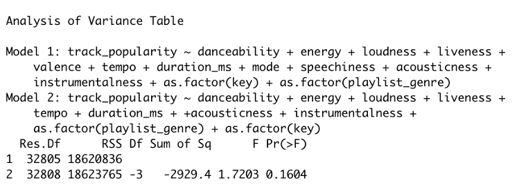

The reduced model has a higher F statistic while maintaining the R-squared value at the same level. The higher F statistic shows the evidence for better model performance. However, in order to the make a determining decision on choosing the best model, we can perform an Analysis on Variable (ANOVA) test on model selections.

According to the ANOVA result, we can see that we cannot reject the null hypothesis at 95% confidence interval. That means that we should adopt the reduced model as the better fit to the original data as the variables for the removed variables are close to 0 and can be rejected.

### Ordinal Logistic Regression

From the analysis above on the multiple regression analysis, although we are improving the model constantly, the R-squared level generally remains at a very low level. One reason for the reasons might be the dataset itself. The dependent variable for the regression model built in previous sections is a quantitatively defined metric that measures the popularity of one specific track. However, this value is an oversimplified value, which might have a lot of potential inaccuracies. Therefore, it is arbitrary to adopt the metric itself as the dependent variable to measure the popularity of a certain track. Another way that might result in a better model fit for the data is to transform the variable track_popularity from a quantitative measure to an ordinal categorical variable.

For the dependent variable in this very specific study, the popularity of the tracks can be categorized into four categories: “Not popular”, “Somewhat popular”, “Popular” and “Very popular”. The categorization of the variable is based on the quantile of the original value for track popularity. From the descriptive statistics shown in table 1, the 75% quantile of the variable track_popularity is at 62. Therefore, we are categorizing all tracks with track_popularity over 62 as “very popular” songs. The specific categorization standard is shown in the table below:

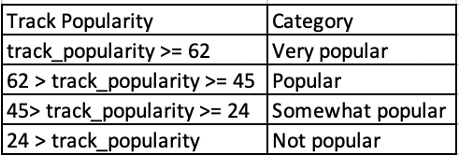

Table 10: Categorization standard for track_popularity

With the dependent variable becoming an ordinal categorical variable, we can perform the ordinal logistic regression to improve the model further to fit the original data.

The ordinal logistic regression estimates the logistic equations for the four categories of the dependent variable track popularity. The model predicts the odds ratio for the dependent variable to move from one category, such as “Not Popular” to the next category, such as “Somewhat Popular”, when the independent variables change. The underlying assumption for ordinal logit is that the number added to each of the logarithms to get the next level is the same in every case. In other words, the odds ratio for each category is assumed to be equal.

4.3.2.1 Ordinal Logistic Regression Output Evaluation

Rstudio Code:

```
{r}
library(VGAM)

vglm <- vglm(popularity_new ~ danceability + energy + loudness + liveness + tempo + duration_ms + acousticness + instrumentalness + as.factor(key) + as.factor(playlist_genre), data = data, family = propodds)
```

```
{r}
coef <- coef(summary(vglm))
coef <- data.frame(coef)
coef[, "p.value"] <- 2*(1 - pnorm(abs(coef[, "z.value"]))) # compute p-values
 # can also add odds ratios to the output
coef$odds.ratio <- exp(coef[, "Estimate"])
coef
```

[figure not shown]

The result of the ordinal logistic model is shown in table 11. We can first look at the overall performance of the model as a whole. The overall determining statistics interested is the log-likelihood value. The log-likelihood value for the ordinal logistic model is -44,041.43, which is significantly higher than that for the best multiple regression model, which is -150,680. The higher log-likelihood value generally indicates a better fit for the model to the original dataset.

However, opposed to liveness and energy, loudness and danceability have negative coefficients. That means that a logit increase in loudness and danceability might cause the song to be categorized into a lower level.

### 5. A Machine Learning Apporoach

Machine Learning is a method that utilizes computer algorithms to automatically improve the model based on the dataset. After utilizing the ordinary least square multiple linear regression models and ordinal logistic models, we can see that the performances of the models overall are not too satisfying. Therefore, it would be interesting to evaluate the data using machine learning approaches for exploratory analyses.

The first method utilized in this section would be logistic models with penalizing terms. The reason I am choosing logistic models with penalizing terms to fit the data is that, with a parametric model, we can examine the relationships among variables more closely and draw conclusions based on the coefficients for the final model.

The main methodology to build penalized logistic model is to split the original data into training dataset and test dataset. The training data is used to fit the model and train on the dataset. The test dataset is used to evaluate the performance of the model.

The first model build is the ridge model, where a logistic model is built on the data with a penalized term alpha to make the coefficients as small as possible. The GridSearchCV is used to tune the alpha parameter in the ridge model. The results are shown below:

Ridge Model

```python
data_final = pd.read_csv("data_final.csv")
```

```python
data_final.head()
```

|  | Unnamed: 0 | track_popularity | danceability | energy | loudness | liveness | valence | tempo | duration_ms | key | playlist_genre | mode | speechiness | acousticness | instrumentalness | key_factor | playlist_genre_factor | poplularity |
| --- | --- | --- | --- | --- | --- | --- | --- | --- | --- | --- | --- | --- | --- | --- | --- | --- | --- | --- |
| 0 | 0 | 66 | 0.748 | 0.916 | -2.634 | 0.0653 | 0.518 | 122.036 | 194754.0 | 6 | pop | 1 | 0.0583 | 0.1020 | 0.000000 | 6 | pop | 0.0 |
| 1 | 1 | 67 | 0.726 | 0.815 | -4.969 | 0.3570 | 0.693 | 99.972 | 162600.0 | 11 | pop | 1 | 0.0373 | 0.0724 | 0.004210 | 11 | pop | 0.0 |
| 2 | 2 | 70 | 0.675 | 0.931 | -3.432 | 0.1100 | 0.613 | 124.008 | 176616.0 | 1 | pop | 0 | 0.0742 | 0.0794 | 0.000023 | 1 | pop | 0.0 |
| 3 | 3 | 60 | 0.718 | 0.930 | -3.778 | 0.2040 | 0.277 | 121.956 | 169093.0 | 7 | pop | 1 | 0.1020 | 0.0287 | 0.000009 | 7 | pop | 1.0 |
| 4 | 4 | 69 | 0.650 | 0.833 | -4.672 | 0.0833 | 0.725 | 123.976 | 189052.0 | 1 | pop | 1 | 0.0359 | 0.0803 | 0.000000 | 1 | pop | 0.0 |

```python
y = data['track_popularity']
X = data[['danceability', 'energy','loudness' , 'liveness' , 'tempo' , 'duration_ms' , 'acousticness', 'instrumentalness','key', 'valence', 'speechiness', 'mode']]
```

```python
X.head()
```

|  | danceability | energy | loudness | liveness | tempo | duration_ms | acousticness | instrumentalness | key | valence | speechiness | mode |
| --- | --- | --- | --- | --- | --- | --- | --- | --- | --- | --- | --- | --- |
| 0 | 0.748 | 0.916 | -2.634 | 0.0653 | 122.036 | 194754.0 | 0.1020 | 0.000000 | 6 | 0.518 | 0.0583 | 1 |
| 1 | 0.726 | 0.815 | -4.969 | 0.3570 | 99.972 | 162600.0 | 0.0724 | 0.004210 | 11 | 0.693 | 0.0373 | 1 |
| 2 | 0.675 | 0.931 | -3.432 | 0.1100 | 124.008 | 176616.0 | 0.0794 | 0.000023 | 1 | 0.613 | 0.0742 | 0 |
| 3 | 0.718 | 0.930 | -3.778 | 0.2040 | 121.956 | 169093.0 | 0.0287 | 0.000009 | 7 | 0.277 | 0.1020 | 1 |
| 4 | 0.650 | 0.833 | -4.672 | 0.0833 | 123.976 | 189052.0 | 0.0803 | 0.000000 | 1 | 0.725 | 0.0359 | 1 |

```python
from sklearn.model_selection import train_test_split

# Use train_test_split(X,y) to create four new data sets, defaults to .75/.25 split
X_train, X_test, y_train, y_test = train_test_split(X, y, random_state = 23)

print(X.shape)
X_train.shape
```

```
(32833, 12)
```

```
(24624, 12)
```

```python
from sklearn.model_selection import GridSearchCV
from sklearn.linear_model import Lasso
from sklearn.linear_model import Ridge



param_grid_ridge = {'alpha':[0.001,0.01,0.1,1,10,100,1000]}
grid_ridge = GridSearchCV(Ridge(), param_grid = param_grid_ridge)
grid_ridge.fit(X_train, y_train)

print("best mean cross-validation score: {:.3f}".format(grid_ridge.best_score_))
print("best parameters: {}".format(grid_ridge.best_params_))
print("test-set score: {:.3f}".format(grid_ridge.score(X_test, y_test)))
```

```
best mean cross-validation score: 0.069
best parameters: {'alpha': 1}
test-set score: 0.079
```

According to the cross-validation score for the gridsearch method, the best alpha parameter for the ridge model is 1, with a cross-validation score around 0.069, which is comparatively low. Therefore, the next step is to try fit a Lasso model to the original dataset.

Lasso Model

Lasso Model uses the same approach as the Ridge model. The only difference between the two models is the penalty term. The Ridge model is a linear model that fits the model based on certain restrictions on the coefficients. A ridge model can create a comparatively simpler model with a trade-off of performance on the training model.

For a lasso model, the coefficients are also restricted to a certain constraint, but, in a lasso model, some coefficients can be exactly zero. That means that the Lasso model will drop the unimportant variables to create an even simpler model compared to a ridge model. The results are shown below:

According to the cross-validation score for the gridsearch method, the best alpha parameter for the lasso model is 0.001 and max_iter at 100. Surprisingly, the Ridge and Lasso model generally produces the same result, which is not the most preferable result for the two models. In order to improve the model accuracy and performance, we can try regressed the model with the target variable being the categorical popularity data.

```python
param_grid_lasso = {'alpha':[0.001,0.01,0.1,1,10,100,1000], 'max_iter' : [10,100,1000,10000,100000]}
grid_lasso = GridSearchCV(Lasso(), param_grid = param_grid_lasso)
grid_lasso.fit(X_train, y_train)

print("best mean cross-validation score: {:.3f}".format(grid_lasso.best_score_))
print("best parameters: {}".format(grid_lasso.best_params_))
print("test-set score: {:.3f}".format(grid_lasso.score(X_test, y_test)))
```

```
best mean cross-validation score: 0.063
best parameters: {'alpha': 0.001, 'max_iter': 100}
test-set score: 0.069
```

Penalized Logistic Model with categorical dependent variable

```python
y1 = data_final['poplularity']
```

```python
X_train1, X_test1, y_train1, y_test1 = train_test_split(X, y1, random_state = 23)

print(X.shape)
X_train.shape
```

```
(32833, 12)
```

```
(24624, 12)
```

```python
from sklearn.linear_model import LogisticRegression

param_grid_penlog = {'C': [0.001,0.01,0.1,1,10,100,1000], "penalty":["l1","l2"]}
grid_penlog = GridSearchCV(LogisticRegression(), param_grid = param_grid_penlog)
grid_penlog.fit(X_train1, y_train1)

print("best mean cross-validation score: {}".format(grid_penlog.best_score_))
print("best parameters: {}".format(grid_penlog.best_params_))
print("test-set score: {}".format(grid_penlog.score(X_test, y_test)))
```

```
best mean cross-validation score: 0.24654808314811535
best parameters: {'C': 0.001, 'penalty': 'l2'}
test-set score: 0.24619320258253136
```

The main methodology utilized to create a penalized logistic model is that we are also performing gridsearch on the penalizing method for the logistic model, which is shown as the penalty parameter in the table below. From the result shown above, we can see that the best model is the one with parameters C = 0.001 and with “l2” ridge model. The cross-validation score is 0.247, which is significantly higher than the results from the other two methods utilized.

## 6. Results and discussion

The research question for this specific study is “What are the factors that makes a song popular on Spotify?” The study mainly utilized three models to fit the original dataset to produce reliable outputs and conclusions.

The first model used is multiple regression model, with track_popularity as a quantitative measure of a song’s popularity. We adopted the reduced model as the best model because the model has a higher F-test and survives from the ANOVA analysis procedure. The result shows that Latin, Pop and Rock are the three most popular genre on Spotify. A song that fits into either of the three categories will have a higher popularity value around 8 compared to other genres. The model also shows that danceability, loudness and acousticness are the three factors that make a song more popular quantitatively. A more danceable, louder and more acoustically driven song is considered to be more popular on Spotify. However, energy, liveness, instrumentalness are the factors that hinder a song to be popular on Spotify. The study also shows that a longer song is generally less popular on Spotify overall.

Although there are some interesting finds derived from the multiple linear regression model, the overall performance of the model is not satisfying. In order to further improve the model, the target variable is transformed into an ordinal categorical variable, and ordinal logit regression is performed on the dataset.

The main methodology used for machine learning model is penalized logistic regression models. Ridge and Lasso models are both used to fit the training data to make predictions. However, both models behave poorly on the training set. Therefore, an underlying explanation to the issue might the dependent variable, as it is an approximation on the quantitative metrics to the popularity. The same models are applied on the dataset where the target variable is the categorical popularity variable. The model accuracy increases from 0.063 to 0.246, which is significant increase in accuracy overall.

Overall, the model with the most predictability is the ridge model with parameter C = 0.001. However, subjectively, the result is not satisfying as well to a certain level. There are some reasons why models are behaving poorly on the dataset.

The first reason is the dataset itself. Most the variables are very opinion-oriented, in other words, most of the variables are just a quantitative approximation to measure certain features of a song. For example, variables like danceability, liveness are very difficult to quantify in numbers. These are mostly derived from opinions and attitudes. Number fails to describe such traits in the society. Granted, it is possible to quantity these features using numbers with a certain degree of accuracy, but the process would be extremely difficult. Even the target variable itself is not precise enough and objective to measure the popularity of the songs in the dataset. It is understandable and reasonable that, after transforming the target variable into a categorical data, the accuracy of models improves.

The second reason is that there are still certain variables not included in the model. For example, playlist_subgenre, which is a more detailed variable that categorize each song into a certain genre. Adding the variable will potentially increase the model predictability, but, in the meantime, will make the model more complicated to analyze and evaluate. Apart from the variables included in the dataset, there are certain variables that are not considered to even be included in the dataset. A possible scenario is that although a song is not categorized as being a popular song quantitatively, just because the song is performed by a certain artist, the popularity of the song goes up. For example, a song might be depressive and sad, but for the performer of the song to be a famous artist, such as Taylor Swift, the song will gain popularity in the meantime disregarding all the other features that are generally included in this research.

Another important variable that is not included in the dataset is the melody, which is hard to measure as well. Music being a popular type of art, is really difficult to quantify using numbers. Analogously, the value of a paint cannot simply be defined as its price. In most of the cases, a song becomes popular because it touches our heart. The melody resonant with our heart beats, and that is something that cannot easily be quantified.

Therefore, for the hypotheses presented at the start of this paper, the first hypothesis is tested to be true to a certain extent. However, the second hypothesis cannot be tested using quantitative methods as melody and uniqueness are extremely difficult, and for most of the cases, impossible to quantify using metrics or values.

## 7. Conclusions

However, the study also shows a lot of shortcomings and issues within the study, because music, as an art form is hard to quantify its features and characteristics. An agreeable conclusion that can be drawn from the study is that art, music included, is difficult or even impossibly to quantify or be given a value. Art can only be appreciated through heart and soul, and spiritual satisfaction cannot be presented or analyzed in a dataset. We are satisfied to see that models and numbers are not omnipotent in all cases. There are certain things that cannot be analyzed using model and numbers, and they are humanity, heart and soul, which is also the true meaning of life.

## 8. Citation

N, Anuja, “L1 and L2 Regularization Methods”, towards data science, Oct 13, 2017, Accessed Dec 19, 2021. https://towardsdatascience.com/l1-and-l2-regularization-methods-ce25e7fc831c

R, Akanksha, “Ordinal Logistic Regression”, towards data science, Feb 20, 2018, Accessed Dec 19, 2021. https://towardsdatascience.com/implementing-and-interpreting-ordinal-logistic-regression-1ee699274cf5

J, Albert, “Evolution of Pop Music”, London Singing Institute, Aug 12, 2020, Accessed Dec 19, 2021. https://www.londonsinginginstitute.co.uk/evolution-of-pop-music/

S, Saishruthi, “Logistic Regression – Detailed Overview”, towards data science, Mar 15, 2018, Accessed Dec 19, 2021. https://towardsdatascience.com/logistic-regression-detailed-overview-46c4da4303bc